# Attainment and Attendance in West Sussex

What the national model behind *How to Pull the Right Lever* says about the county’s secondary schools, with comparisons to East Sussex and Brighton and Hove. **Draft for discussion.**

Author

Affiliation

Adam Dennett

Bartlett Centre for Advanced Spatial Analysis, University College London

Published

October 30, 2026

**WarningDraft for discussion**

A first draft, written as a companion to the East Sussex document and to [How to Pull the Right Lever](https://adamdennett.github.io/school_attainment_tool/pulling_the_right_lever_v2.html). Every figure comes from published Department for Education data and the national models documented there. Nothing uses pupil-level records.

# Summary

**West Sussex’s results look ordinary, but its pupils should be doing better.** In 2024-25 the county’s 40 state-funded secondary schools averaged 46.4 in Attainment 8, close to England’s 46.9 (71st of 152 authorities). But its schools are among the least disadvantaged in England (17.1% against 28.3%, 10th lowest). Its disadvantaged pupils average 33.5, against 37.8 nationally (127th).

- **The county’s schools get less from their pupils than the model expects, and this is the main finding.** Once intake and circumstances are accounted for, West Sussex ranks 115th of 152 for all pupils. For disadvantaged pupils it ranks 131st of 151, significantly below average. The local authority effect costs disadvantaged pupils about 1.5 Attainment 8 points.
- **Absence is not the explanation here, unlike in East Sussex and Brighton and Hove.** The county’s absence (8.1% in autumn and spring 2025/26) is close to England’s (8.0%) and almost exactly what its intake predicts. Controlling for it makes no difference to the county’s standing: 132nd with it, 133rd without.
- **What absence there is has a distinctive shape.** Illness runs above the national rate and unauthorised absence below it. Reduced timetables run at 1.9 times the national rate, the clearest outlier in the county’s absence profile.
- **Crawley is a real district effect.** All 7 of its schools sit below expectation. For non-disadvantaged pupils its effect survives even when each school’s own record is taken into account, the only district in Sussex where it does.
- **Who runs a school matters less than which school it is.** 18 of the county’s schools are maintained and 21 are in multi-academy trusts. United Learning’s three West Sussex schools are among the county’s strongest. The Kemnal Academies Trust’s schools run significantly more absence than their intakes predict.

# 1 About this analysis

This document applies the national models of the Lever report to West Sussex in the same way the East Sussex document does for that county. Its sections follow the same order, and its methods are described in full there. In brief:

- **The models are the published ones:** multilevel models of school-level Attainment 8 for every state-funded mainstream secondary school in England, 2021/22 to 2024/25, for all, disadvantaged and non-disadvantaged pupils. They explain around 80% of the variation between schools.
- **Three sections refit copies of them** to ask questions the published versions cannot: Section 5.1 adds a district level, Section 5.2 a multi-academy trust level, and Section 7.1 separates absence from intake.
- **Absence runs to autumn and spring 2025/26**, and the value-added tables include provisional 2025/26 results.
- **The models describe schools, not pupils.** They show how strongly a school’s characteristics and its results move together across England. They cannot show that one causes the other for any child, and the scenarios are indications of scale, not forecasts.

# 2 The county’s schools

[interactive chart not shown]

West Sussex’s state-funded secondary schools, coloured by overall absence in 2024/25, within the county’s seven districts and boroughs. Choose another measure from the menu above the map; circle size is the school’s roll. Hover over a school for its figures and who runs it.

West Sussex has 40 state-funded mainstream secondary schools teaching 51,334 pupils, across seven districts and boroughs:

- **Crawley**, a new town by Gatwick.
- **The market towns of Horsham and Mid Sussex.**
- **The coast**, from Selsey and Bognor Regis through Littlehampton and Worthing to Shoreham.
- **Chichester and its rural hinterland.**

All the schools are non-selective. 4 are Catholic and 5 Church of England. Like East Sussex, the county also has a large independent sector, which is outside these models.

Schools by district and borough, 2024/25. Unweighted school means.

| District | Schools | Pupils | FSM % | Absence % | Persistent absence % | KS2 (centred) | Attainment 8 | Attainment 8, disadvantaged |
| --- | --- | --- | --- | --- | --- | --- | --- | --- |
| Crawley | 7 | 9,213 | 23.4 | 9.3 | 26.3 | 3.8 | 42.1 | 30.7 |
| Adur | 2 | 3,189 | 20.0 | 8.3 | 22.8 | 4.6 | 48.4 | 40.0 |
| Arun | 6 | 7,935 | 18.6 | 9.1 | 26.3 | 3.3 | 43.1 | 31.2 |
| Chichester | 6 | 6,303 | 17.8 | 8.9 | 24.9 | 3.8 | 43.6 | 31.0 |
| Worthing | 6 | 6,700 | 17.6 | 8.4 | 23.0 | 4.2 | 49.0 | 35.8 |
| Mid Sussex | 7 | 9,471 | 12.2 | 8.3 | 21.3 | 5.0 | 50.3 | 35.5 |
| Horsham | 6 | 8,523 | 11.9 | 8.0 | 21.7 | 5.4 | 49.6 | 34.6 |

The county divides sharply. Horsham and Mid Sussex are the least disadvantaged districts in Sussex (11.9 to 12.2% eligible for free school meals), arrive with the highest prior attainment and average over 49 in Attainment 8. Crawley is the most disadvantaged (23%). It has the lowest results (42.1), and its disadvantaged pupils average 30.7. The coastal districts of Arun and Chichester sit between, with results almost as low as Crawley’s on a less disadvantaged intake.

Every state-funded secondary school, 2024/25. KS2 is the cohort’s mean Key Stage 2 score, centred as in the national model (England’s school average is about 4.5).

| School | District | Type | Pupils | FSM % | Absence % | Persistent % | KS2 | EHCP % | Att 8 | Att 8 disadv. | Ofsted |
| --- | --- | --- | --- | --- | --- | --- | --- | --- | --- | --- | --- |
| Shoreham Academy | Adur | Academy | 1777 | 15.0 | 7.4 | 18.0 | 4.7 | 3.7 | 54.8 | 47.7 | Outstanding |
| The Sir Robert Woodard Academy | Adur | Academy | 1412 | 24.9 | 9.3 | 27.7 | 4.4 | 3.6 | 42.0 | 32.2 | Good |
| Felpham Community College | Arun | Maintained | 1557 | 16.3 | 8.8 | 26.3 | 3.7 | 1.1 | 41.9 | 29.7 | Good |
| Ormiston Six Villages Academy | Arun | Academy | 698 | 15.3 | 7.8 | 26.9 | 2.6 | 2.2 | 42.8 | 30.7 | Good |
| St Philip Howard Catholic School | Arun | Academy | 1301 | 14.2 | 6.9 | 16.6 | 4.6 | 3.1 | 52.5 | 37.5 | Outstanding |
| The Angmering School | Arun | Maintained | 1345 | 16.9 | 10.3 | 29.9 | 3.0 | 5.3 | 41.0 | 27.2 | Good |
| The Littlehampton Academy | Arun | Academy | 1369 | 23.7 | 12.7 | 35.0 | 3.7 | 3.4 | 37.2 | 26.7 | Good |
| The Regis School | Arun | Academy | 1665 | 25.3 | 8.1 | 23.3 | 2.2 | 1.9 | 43.5 | 35.4 | Good |
| Bishop Luffa School, Chichester | Chichester | Academy | 1579 | 8.9 | 6.9 | 16.6 | 5.8 | 2.1 | 52.5 | 28.5 | Outstanding |
| Bourne Community College | Chichester | Maintained | 729 | 22.4 | 8.6 | 26.4 | 3.4 | 5.6 | 39.0 | 25.5 | Good |
| Chichester Free School | Chichester | Academy | 1078 | 14.5 | 8.1 | 22.7 | 3.6 | 1.2 | 44.6 | 35.5 | Good |
| Chichester High School | Chichester | Academy | 1258 | 23.5 | 10.7 | 34.0 | 3.5 | 2.0 | 38.9 | 30.3 | Good |
| Midhurst Rother College | Chichester | Academy | 1158 | 14.8 | 8.1 | 19.4 | 3.9 | 2.2 | 48.6 | 34.7 | Outstanding |
| The Academy, Selsey | Chichester | Academy | 501 | 22.7 | 11.1 | 30.4 | 2.5 | 4.3 | 37.9 | 31.7 | Good |
| Hazelwick School | Crawley | Academy | 1890 | 20.5 | 6.6 | 15.5 | 4.5 | 1.9 | 50.1 | 38.2 | Outstanding |
| Holy Trinity CofE Secondary School, Crawley | Crawley | Maintained | 1359 | 27.2 | 11.9 | 35.2 | 4.1 | 1.3 | 41.6 | 32.9 | Good |
| Ifield Community College | Crawley | Maintained | 1204 | 28.8 | 10.9 | 31.4 | 2.5 | 1.1 | 40.0 | 31.9 | Good |
| Oriel High School | Crawley | Maintained | 1478 | 12.5 | 8.8 | 26.4 | 5.1 | 2.1 | 45.2 | 27.2 | Good |
| St Wilfrid's Catholic Comprehensive School, Crawley | Crawley | Maintained | 1174 | 13.7 | 6.5 | 16.4 | 6.1 | 3.5 | 45.0 | 30.7 | Good |
| The Gatwick School | Crawley | Academy | 846 | 23.2 | 9.2 | 27.0 | 1.8 | 1.6 | 39.5 | 28.2 | Good |
| Thomas Bennett Community College | Crawley | Academy | 1262 | 38.1 | 11.6 | 32.1 | 2.6 | 2.8 | 33.0 | 25.6 | Good |
| Bohunt Horsham | Horsham | Academy | 1121 | 12.0 | 7.3 | 17.6 | 6.7 | 2.2 | 49.4 | 36.1 | Good |
| Millais School | Horsham | Maintained | 1055 | 12.8 | 8.7 | 22.6 | 6.4 | 1.3 | 51.5 | 33.7 | Good |
| Steyning Grammar School | Horsham | Academy | 1944 | 13.6 | 9.3 | 27.8 | 3.8 | 2.3 | 48.6 | 35.1 | Requires Improvement |
| Tanbridge House School | Horsham | Maintained | 1524 | 9.7 | 7.0 | 17.6 | 5.5 | 1.8 | 54.2 | 34.1 | Outstanding |
| The Forest School | Horsham | Maintained | 1095 | 7.4 | 7.8 | 22.5 | 5.0 | 2.6 | 46.9 | 34.2 | Good |
| Weald School, The | Horsham | Maintained | 1784 | 16.2 | 8.0 | 22.2 | 4.8 | 1.9 | 47.1 | 34.3 | Outstanding |
| Downlands Community School | Mid Sussex | Maintained | 1250 | 7.4 | 7.6 | 19.1 | 5.7 | 1.4 | 57.2 | 45.7 | Good |
| Imberhorne School | Mid Sussex | Maintained | 1573 | 13.2 | 9.5 | 26.2 | 3.6 | 2.5 | 45.0 | 26.2 | Good |
| Oathall Community College | Mid Sussex | Maintained | 1303 | 16.9 | 7.9 | 20.4 | 5.2 | 2.2 | 51.5 | 35.8 | Good |
| Sackville School | Mid Sussex | Maintained | 1599 | 12.9 | 9.9 | 28.0 | 3.5 | 2.6 | 46.0 | 34.9 | Good |
| St Paul's Catholic College | Mid Sussex | Academy | 1190 | 7.7 | 5.8 | 12.8 | 6.8 | 2.1 | 55.4 | 42.5 | Outstanding |
| The Burgess Hill Academy | Mid Sussex | Academy | 1018 | 19.1 | 10.0 | 22.2 | 3.5 | 1.4 | 44.6 | 33.2 | Good |
| Warden Park Secondary Academy | Mid Sussex | Academy | 1538 | 8.2 | 7.7 | 20.4 | 6.5 | 3.3 | 52.3 | 30.1 | Good |
| Bohunt School Worthing | Worthing | Academy | 897 | 13.5 | 8.3 | 23.4 | 4.9 | 4.8 | 46.7 | 30.3 | Good |
| Davison Church of England High School for Girls, Worthing | Worthing | Maintained | 1328 | 15.5 | 8.3 | 21.9 | 5.2 | 3.3 | 52.1 | 35.9 | Outstanding |
| Durrington High School | Worthing | Academy | 1606 | 19.6 | 8.8 | 24.4 | 3.5 | 1.7 | 49.7 | 36.3 | Good |
| St Andrew's CofE High School | Worthing | Maintained | 739 | 21.5 | 11.1 | 32.7 | 3.2 | 2.5 | 41.7 | 36.2 | Good |
| St Oscar Romero Catholic School | Worthing | Maintained | 1075 | 18.5 | 5.2 | 14.2 | 3.9 | 4.0 | 55.1 | 38.2 | Good |
| Worthing High School | Worthing | Academy | 1055 | 16.7 | 8.9 | 21.5 | 4.4 | 5.5 | 48.5 | 37.9 | Good |

## 2.1 Who runs the county’s schools

Nearly half of West Sussex’s secondary schools are still maintained. In 2024/25:

- **18 were maintained** by the county council.
- **21 were in 12 multi-academy trusts.** These range from national trusts (United Learning, Ormiston, Kemnal, Woodard) to local ones of two or three schools.
- **1 was a single-academy trust.**

9 academies are sponsored: placed with a trust, usually because they were struggling. They are mostly on the coast.

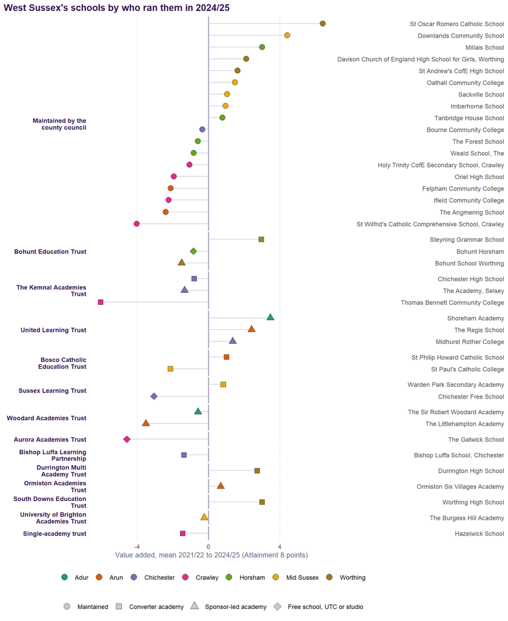

Figure 1: Who ran each school in 2024/25, and how far its results sat above or below the national model’s expectation over 2021/22 to 2024/25 (Attainment 8 points). Each panel is a governing body; each dot a school, coloured by district and shaped by how it came to be run that way.

Table 1: Schools whose governing body has changed since 2024/25, from Get Information about Schools (October 2026).

| School | District | Run by, 2024/25 | Run by now |
| --- | --- | --- | --- |
| The Burgess Hill Academy | Mid Sussex | University of Brighton Academies Trust | Sussex Learning Trust |
| The Forest School | Horsham | Maintained by the county council | Horsham Learning Alliance |
| Ifield Community College | Crawley | Maintained by the county council | The Collegiate Trust |

Governance shows no simple pattern. The strongest school on value added, St Oscar Romero in Worthing, is maintained. So are several of the weakest, including St Wilfrid’s in Crawley. United Learning’s three sponsored academies are all above expectation. Section 5.2 asks the question formally.

# 3 How West Sussex compares

West Sussex, East Sussex, Brighton and Hove and England, 2024/25. Means of school-level figures; ranks among all local authorities (1 = highest).

| Measure | West Sussex | East Sussex | Brighton and Hove | England |
| --- | --- | --- | --- | --- |
| Attainment 8, all pupils | 46.4 (71st) | 43.8 (120th) | 45.5 (85th) | 46.8 |
| Attainment 8, disadvantaged | 33.5 (127th) | 33.0 (135th) | 33.9 (122nd) | 37.7 |
| Attainment 8, non-disadvantaged | 48.9 (83rd) | 47.5 (118th) | 49.6 (68th) | 49.9 |
| Disadvantage gap (points) | 15.4 (16th) | 14.5 (29th) | 15.7 (13th) | 12.2 |
| Disadvantaged (FSM6) % | 17.1 (143rd) | 25.5 (89th) | 28.8 (74th) | 28.4 |
| Overall absence % | 8.7 (71st) | 9.7 (27th) | 11.3 (1st) | 8.6 |
| Persistent absence % | 23.9 (79th) | 26.4 (31st) | 30.6 (4th) | 23.9 |
| Mean KS2 (centred) | 4.26 (79th) | 3.79 (112th) | 4.71 (50th) | 4.47 |
| EAL % | 11.0 (97th) | 6.3 (130th) | 13.0 (83rd) | 18.4 |
| EHC plan % | 2.6 (100th) | 2.2 (128th) | 4.1 (12th) | 2.9 |

Against England, West Sussex has:

- **average results** overall, but a wide disadvantage gap (15.4 points, 16th widest);
- **few disadvantaged pupils** (17.1%);
- **average absence** (8.7% on the school-mean measure);
- **slightly lower prior attainment** than the national average, despite its affluence.

That combination is the puzzle. A county this advantaged would be expected to sit well above the national average. It sits on it.

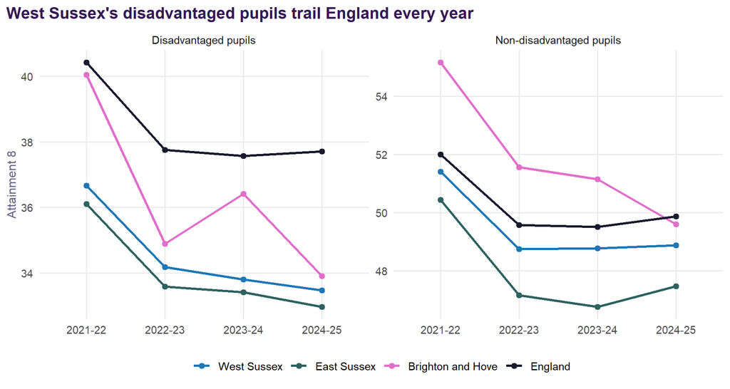

Attainment 8 for disadvantaged and non-disadvantaged pupils, school means, 2021/22 to 2024/25.

# 4 What explains attainment in West Sussex

The national model’s prediction for each school adds up exactly, factor by factor, to the gap between an area’s average and England’s. The East Sussex document explains the method.

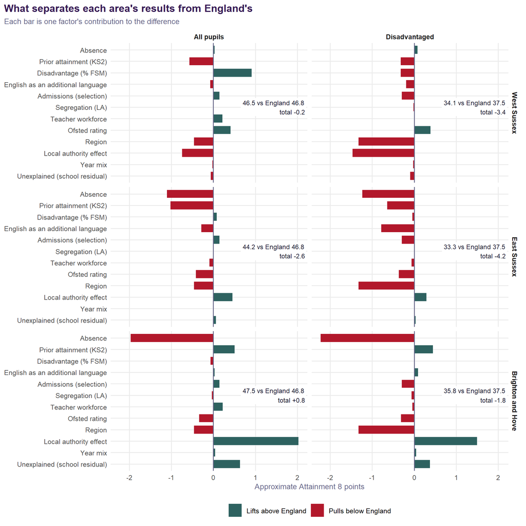

Figure 2: Why average Attainment 8 differs from England’s, by factor, all school-years 2021/22 to 2024/25. Approximate Attainment 8 points; the pieces sum to the total printed in each panel.

The decomposition for West Sussex, in Attainment 8 points. Region and local authority together are ‘place’.

| Factor | All pupils | Disadvantaged | Non-disadvantaged |
| --- | --- | --- | --- |
| Place (region and local authority) | -1.20 | -2.79 | -1.48 |
| Prior attainment (KS2) | -0.57 | -0.32 | -0.46 |
| English as an additional language | -0.07 | -0.19 | -0.10 |
| Unexplained (school residual) | -0.06 | -0.09 | -0.06 |
| Absence | +0.03 | +0.08 | +0.06 |
| Other model terms | +0.12 | -0.34 | +0.10 |
| Teacher workforce | +0.21 | +0.02 | +0.21 |
| Ofsted rating | +0.41 | +0.39 | +0.39 |
| Disadvantage (% FSM) | +0.91 | -0.32 | +0.47 |

**For all pupils**, West Sussex is only 0.2 points below England, but that small total hides large pieces pulling in opposite directions:

- **Lifting the county:**
  - its low disadvantage (+0.91);
  - better Ofsted ratings (+0.41);
  - its teacher workforce (+0.21).
- **Pulling it down:**
  - lower prior attainment (-0.57);
  - place (-1.20), of which the county’s own effect is -0.74.

Absence contributes almost nothing either way (+0.03).

**For disadvantaged pupils** the gap is 3.4 points, and almost all of it is place: -2.79 points, of which -1.47 is the county’s own effect. The rest is the South East’s regional effect, which East Sussex shares.

**This is the sharpest contrast in Sussex.**

- In **East Sussex**, the gap is absence and prior attainment, and the county’s schools do about what is expected.
- In **Brighton and Hove**, absence costs the most, and the city’s schools more than make up for it.
- In **West Sussex**, absence is not the issue. The county’s schools get less than expected from pupils who are, on paper, advantaged, and most of all from those who are not.

# 5 The county’s own effect

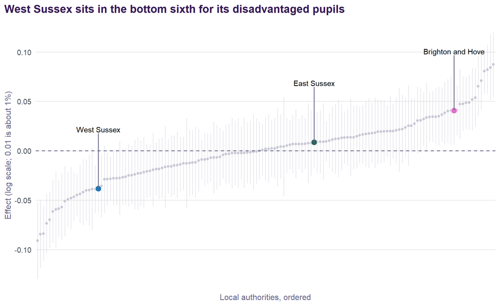

Figure 3: Local authority effects from the published national models, disadvantaged pupils, every authority in England with a 95% interval.

Table 2: Local authority effects and ranks (1 = best). ‘Significant’ means the 95% interval excludes zero.

| Group | Local authority | Effect (%) | Rank | Significant |
| --- | --- | --- | --- | --- |
| All pupils | Brighton and Hove | +4.5 | 5th of 152 | Yes |
| All pupils | East Sussex | +1.1 | 49th of 152 | No |
| All pupils | West Sussex | -1.5 | 115th of 152 | No |
| Disadvantaged | Brighton and Hove | +4.2 | 14th of 151 | Yes |
| Disadvantaged | East Sussex | +0.9 | 60th of 151 | No |
| Disadvantaged | West Sussex | -3.8 | 131st of 151 | Yes |
| Non-disadvantaged | Brighton and Hove | +5.0 | 4th of 151 | Yes |
| Non-disadvantaged | East Sussex | +1.2 | 50th of 151 | No |
| Non-disadvantaged | West Sussex | -2.3 | 124th of 151 | Yes |

West Sussex’s schools sit below expectation for every group:

- **disadvantaged pupils:** -3.8%, 131st;
- **non-disadvantaged pupils:** -2.3%, 124th.

Both are significant. This is a county-wide pattern across 40 schools and four years, not one or two schools.

Unlike Brighton and Hove, the ranking does not depend on absence. With the absence control the county is 132nd for disadvantaged pupils; without it, 133rd. The county’s attendance is not hiding effective schools, and it is not what holds the schools back.

What the model cannot say is *why*. The local authority effect is whatever the county’s schools share that the model does not measure:

- how schools are supported and challenged;
- how pupil premium funding is used;
- curriculum and entry decisions;
- the recruitment market in the county;
- the expectations families and schools hold.

Identifying it would need the county’s own knowledge. This document can only point to it.

## 5.1 Do the districts differ?

The district test in the East Sussex document was run for every district in England. A district level is added to the national model, once on the published specification and once with each school’s own record in the model too.

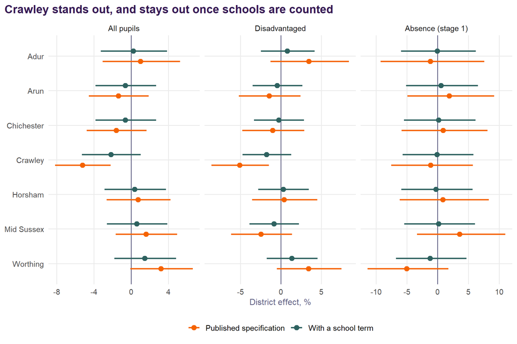

Figure 4: West Sussex’s seven districts: district effect on Attainment 8 (all pupils and disadvantaged) and on absence, with 95% intervals, before and after adding a school term. Effects are over and above the county’s own effect.

On the published specification:

A plain comparison of the county’s 40 schools agrees that value added differs by district (F = 4.8, p = 0.001).

**Crawley is different from Hastings.** In East Sussex, Hastings’ effect disappeared once each school’s own record was in the model, because it was two schools. In Crawley:

- **every school is below expectation.** All 7 have negative value added over the four years, from -1.1 to -6.0 points.
- **for non-disadvantaged pupils the district effect survives** the school term (-3.5%), the only district in Sussex where any effect does.

The Crawley schools are of every kind:

- maintained community schools;
- a Church of England and a Catholic school;
- a converter academy in a national trust;
- a single-academy trust;
- a free school.

What they share is the town. That is the closest thing in this analysis to a genuine place effect, and it is worth the county’s attention.

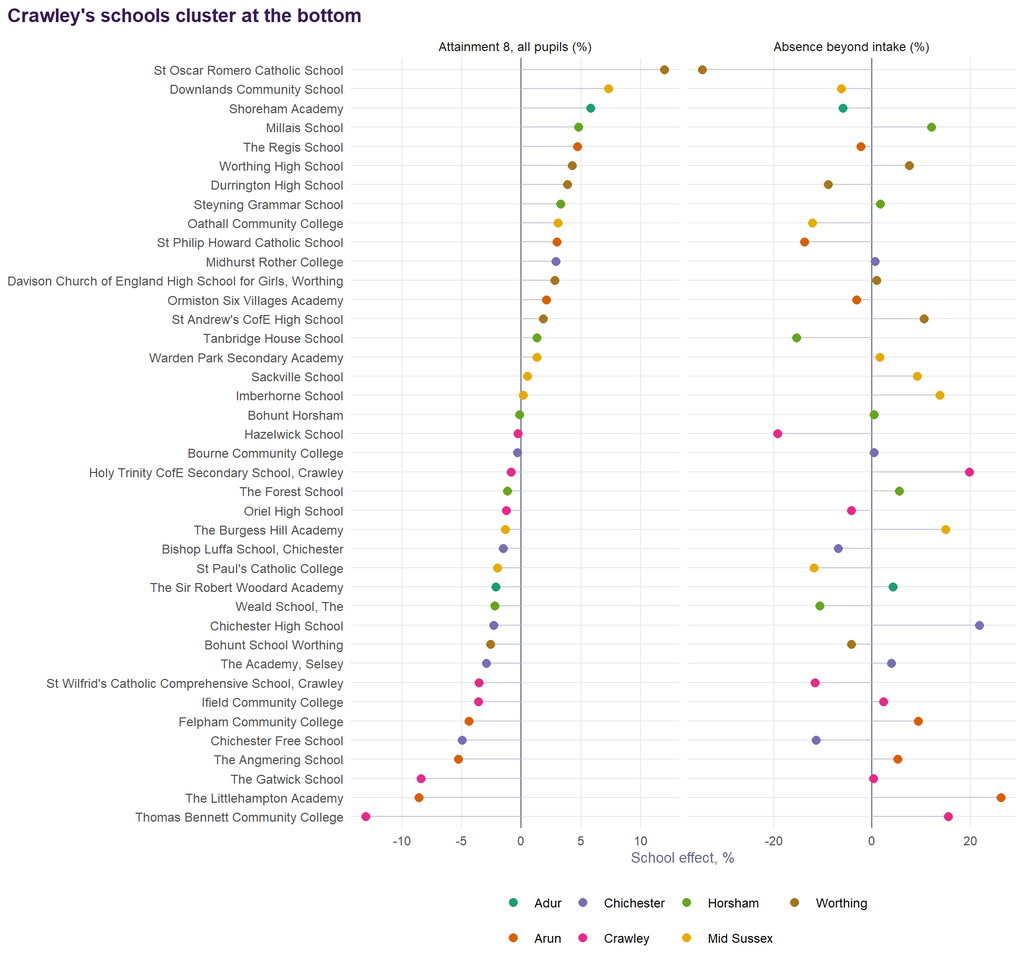

Figure 5: Each West Sussex school’s own persistent effect from the model with a school term, coloured by district: Attainment 8 (all pupils) and absence beyond what its intake predicts.

## 5.2 Do trusts make a difference?

The trust test is described fully in the East Sussex document. Nationally, schools in the same multi-academy trust share an effect of about 2.2% on Attainment 8, about the same as the local authority. It rises to 3.7% for disadvantaged pupils and 6.7% for absence. The test allows for the route each school took (sponsored, converter or maintained), because trusts are often given schools that were already struggling.

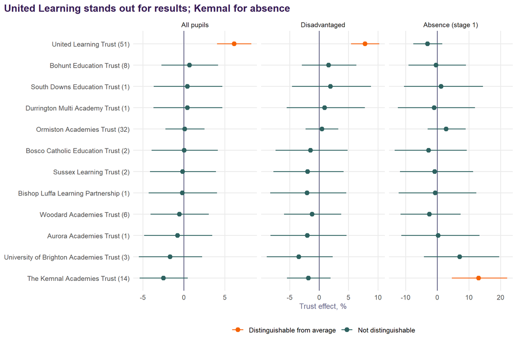

Figure 6: The national effect of each trust that ran a West Sussex school in 2024/25, with 95% intervals, estimated across all its secondary schools in England (number in brackets).

Two of the county’s trusts stand out nationally:

- **United Learning Trust** runs Midhurst Rother College, The Regis School and Shoreham Academy. All three are sponsored academies, and all three are above expectation. Nationally, its schools are +6.1% above what their intakes predict, and +7.8% for disadvantaged pupils. This is evidence that sponsored schools on the coast can be turned around.
- **The Kemnal Academies Trust** runs Thomas Bennett Community College in Crawley, Chichester High School and The Academy, Selsey. Its schools run +13% more absence than their intakes predict, significantly more than average. They are also -2.7% below expectation for non-disadvantaged pupils. Thomas Bennett has the lowest value added in the county.

The other trusts, including Bohunt, Ormiston, Woodard, Bosco and the county’s small local trusts, cannot be distinguished from average.

# 6 Absence in West Sussex

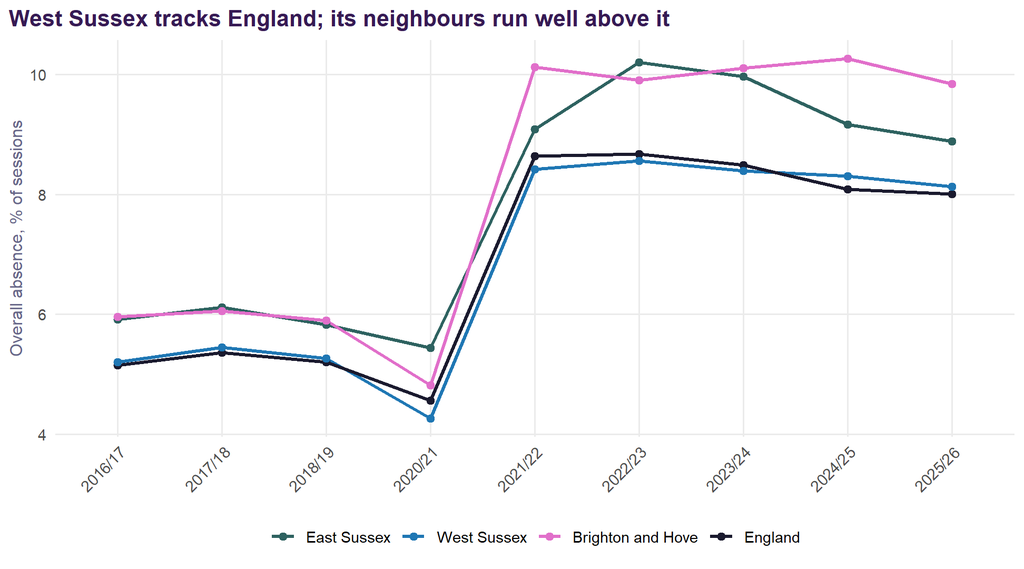

Figure 7: Overall absence in state-funded secondary schools, autumn and spring terms, 2016/17 to 2025/26. Sessions-weighted; 2019/20 was not collected.

Table 3: Secondary absence and persistent absence, autumn and spring terms, with rank among local authorities (1 = highest absence).

| Year | West Sussex: absence / persistent | England |
| --- | --- | --- |
| 2016/17 | 5.2% (72nd) / 12.9% (72nd) | 5.2% / 12.8% |
| 2017/18 | 5.4% (59th) / 13.8% (76th) | 5.4% / 13.6% |
| 2018/19 | 5.3% (66th) / 12.9% (67th) | 5.2% / 12.7% |
| 2020/21 | 4.3% (98th) / 10.7% (95th) | 4.6% / 11.7% |
| 2021/22 | 8.4% (89th) / 26.2% (86th) | 8.6% / 26.7% |
| 2022/23 | 8.6% (80th) / 25.3% (76th) | 8.7% / 25.2% |
| 2023/24 | 8.4% (81st) / 23.9% (79th) | 8.5% / 23.9% |
| 2024/25 | 8.3% (63rd) / 22.6% (62nd) | 8.1% / 21.9% |
| 2025/26 | 8.1% (70th) / 21.4% (78th) | 8.0% / 21.6% |

West Sussex’s absence has tracked England’s closely for a decade. In 2025/26 it was 8.1% (70th of 152), and the county’s absence is almost exactly what its intake predicts: +0.03 points, 92nd of 151. It is not the problem that it is in East Sussex or Brighton and Hove.

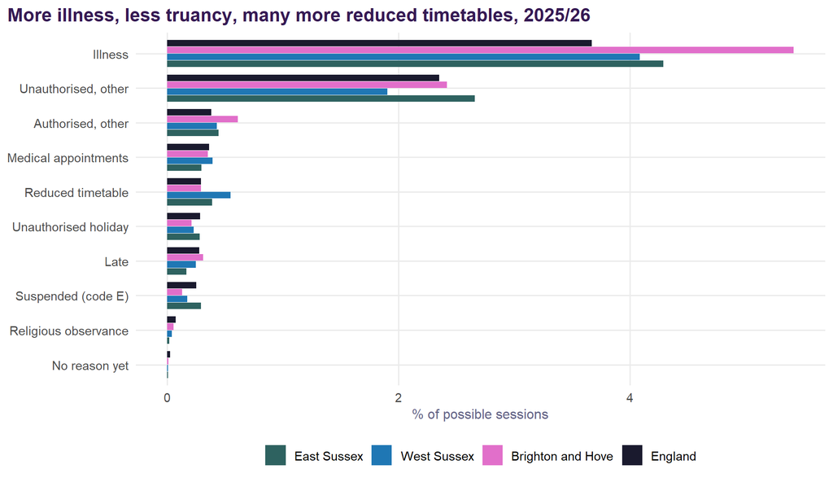

Figure 8: Absence by register reason, autumn and spring terms, percentage of possible sessions. The ten largest reasons nationally.

Table 4: West Sussex against England, by reason, in percentage points of possible sessions.

| Reason | West Sussex | England | Gap | Share of gap |
| --- | --- | --- | --- | --- |
| Unauthorised, other | 1.91 | 2.35 | -0.45 | -372% |
| Illness | 4.09 | 3.67 | +0.41 | 344% |
| Reduced timetable | 0.55 | 0.29 | +0.26 | 216% |
| Suspended (code E) | 0.18 | 0.25 | -0.07 | -62% |
| Unauthorised holiday | 0.23 | 0.29 | -0.05 | -45% |
| Authorised, other | 0.43 | 0.38 | +0.05 | 41% |
| Religious observance | 0.04 | 0.08 | -0.04 | -30% |
| Medical appointments | 0.40 | 0.36 | +0.03 | 26% |
| Late | 0.25 | 0.28 | -0.03 | -24% |
| No reason yet | 0.01 | 0.03 | -0.02 | -16% |
| Interview | 0.03 | 0.02 | +0.02 | 15% |

The profile is unusual, even though the total is not. Against England:

- **Illness is higher:** 4.09 against 3.67% of sessions.
- **Unauthorised absence is lower:** 1.91 against 2.35%. The two roughly cancel.
- **Reduced timetables stand out:** 0.55% of sessions, 1.9 times England’s rate and the highest of the three Sussex authorities.

A reduced timetable is a decision made within the system, usually for a pupil with additional needs while support or a placement is arranged. At this rate it is worth the county knowing who these pupils are and how long they stay on them.

Suspensions, in contrast, are below the national rate: 16.2 per 100 pupils in 2024/25, against 21.2 for England and 28.0 for East Sussex (94th of 152).

# 7 What absence costs, school by school

## 7.1 Two signals

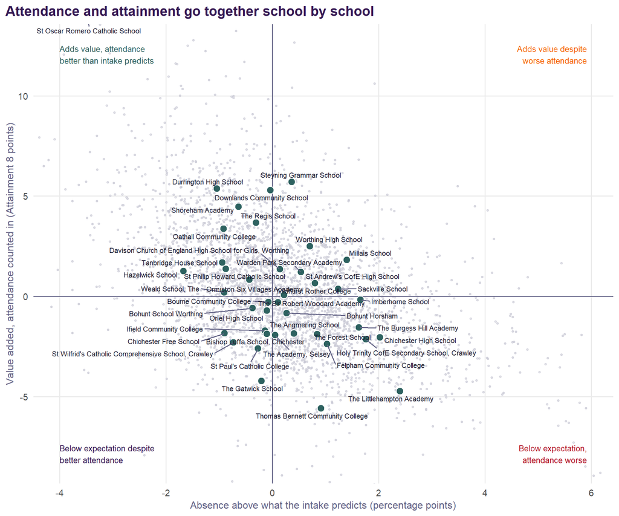

Figure 9: West Sussex schools on the joint-signal plane, mean over 2021/22 to 2024/25: absence above or below what the intake predicts (horizontal) against value added with attendance counted in (vertical). Grey: every school in England.

As in East Sussex, the two signals go together across the county’s schools (correlation -0.58). But the spread is mainly vertical. West Sussex’s schools differ more in what they add than in how they manage attendance. Two schools are furthest from the centre:

- **St Oscar Romero in Worthing**, far above, with attendance well better than its intake predicts.
- **Thomas Bennett Community College in Crawley**, the lowest.

## 7.2 What closing the gap would be worth

Table 5: Predicted Attainment 8 gain if each school’s absence fell to the national school average (2024/25), and if its disadvantage fell to the county average. Indicative only.

| School | District | Absence % | FSM % | Gain, all pupils | Gain, disadvantaged | Gain from FSM to area average |
| --- | --- | --- | --- | --- | --- | --- |
| The Littlehampton Academy | Arun | 12.7 | 23.7 | +3.1 | +3.3 | +0.6 |
| Holy Trinity CofE Secondary School, Crawley | Crawley | 11.9 | 27.2 | +3.0 | +3.4 | +1.0 |
| St Andrew's CofE High School | Worthing | 11.1 | 21.5 | +2.3 | +2.9 | +0.5 |
| Thomas Bennett Community College | Crawley | 11.6 | 38.1 | +2.1 | +2.4 | +1.3 |
| The Academy, Selsey | Chichester | 11.1 | 22.7 | +2.1 | +2.6 | +0.5 |
| Ifield Community College | Crawley | 10.9 | 28.8 | +2.0 | +2.4 | +1.1 |
| Chichester High School | Chichester | 10.7 | 23.5 | +1.8 | +2.0 | +0.6 |
| The Angmering School | Arun | 10.3 | 16.9 | +1.6 | +1.5 | +0.0 |
| The Burgess Hill Academy | Mid Sussex | 10.0 | 19.1 | +1.4 | +1.6 | +0.2 |
| Sackville School | Mid Sussex | 9.9 | 12.9 | +1.4 | +1.5 | +0.0 |
| Imberhorne School | Mid Sussex | 9.5 | 13.2 | +1.0 | +0.8 | +0.0 |
| Steyning Grammar School | Horsham | 9.3 | 13.6 | +0.8 | +0.8 | +0.0 |
| The Sir Robert Woodard Academy | Adur | 9.3 | 24.9 | +0.7 | +0.7 | +0.8 |
| The Gatwick School | Crawley | 9.2 | 23.2 | +0.5 | +0.6 | +0.6 |
| Worthing High School | Worthing | 8.9 | 16.7 | +0.3 | +0.4 | +0.0 |
| Durrington High School | Worthing | 8.8 | 19.6 | +0.3 | +0.3 | +0.3 |
| Oriel High School | Crawley | 8.8 | 12.5 | +0.3 | +0.2 | +0.0 |
| Felpham Community College | Arun | 8.8 | 16.3 | +0.3 | +0.3 | +0.0 |
| Millais School | Horsham | 8.7 | 12.8 | +0.1 | +0.1 | +0.0 |
| Bourne Community College | Chichester | 8.6 | 22.4 | +0.0 | +0.0 | +0.5 |
| Hazelwick School | Crawley | 6.6 | 20.5 | +0.0 | +0.0 | +0.5 |
| The Regis School | Arun | 8.1 | 25.3 | +0.0 | +0.0 | +0.9 |
| St Oscar Romero Catholic School | Worthing | 5.2 | 18.5 | +0.0 | +0.0 | +0.2 |

20 of the county’s 40 schools are above the national average absence. The gains are smaller than in East Sussex: up to 3.1 points at The Littlehampton Academy and Holy Trinity in Crawley, and an average of 1.3 across the 20. Attendance still beats redistribution of disadvantage, which buys at most 1.3 points. But in West Sussex neither is where the main gain lies. That is the gap between what the county’s schools achieve and what the model expects of them.

# 8 School by school: contextual league tables

**All pupils**

Value added, all pupils: observed Attainment 8 minus the national model’s expectation, in points. 2025/26 is provisional.

| School | 2021/22 | 2022/23 | 2023/24 | 2024/25 | 2025/26 | Mean | Years |
| --- | --- | --- | --- | --- | --- | --- | --- |
| St Oscar Romero Catholic School | +7.7 | +7.3 | +4.9 | +5.6 | +5.8 | +6.3 | 5 |
| Downlands Community School | +3.3 | +3.4 | +4.4 | +6.1 | +7.4 | +4.9 | 5 |
| Millais School | +5.4 | +1.8 | +2.9 | +1.6 | +2.6 | +2.9 | 5 |
| Durrington High School | +2.4 | +1.0 | +2.0 | +5.2 | +3.8 | +2.9 | 5 |
| The Regis School | +6.1 | +1.2 | +1.5 | +0.3 | +4.7 | +2.8 | 5 |
| Steyning Grammar School |  |  | +0.4 | +5.0 | +2.5 | +2.7 | 3 |
| Shoreham Academy | +2.7 | +3.0 | +3.9 | +3.9 | -0.9 | +2.5 | 5 |
| Worthing High School | +3.8 | +2.6 | +2.4 | +3.0 | -1.6 | +2.0 | 5 |
| Davison Church of England High School for Girls, Worthing | +3.0 | +1.1 | +1.5 | +2.3 | +0.1 | +1.6 | 5 |
| St Andrew's CofE High School | +1.3 | +0.4 | +3.9 | +0.6 | +1.7 | +1.6 | 5 |
| Oathall Community College | -1.5 | +2.2 | +1.4 | +3.0 | +2.2 | +1.5 | 5 |
| Imberhorne School | -0.3 | +2.5 | +0.5 | +0.9 | +2.0 | +1.1 | 5 |
| Tanbridge House School | -0.3 | +2.3 | -0.1 | +0.5 | +2.6 | +1.0 | 5 |
| Sackville School | +0.8 | +1.1 | -0.2 | +1.9 | +1.3 | +1.0 | 5 |
| Midhurst Rother College | +1.4 | +4.1 | -1.1 | +0.8 | -0.7 | +0.9 | 5 |
| Warden Park Secondary Academy | -0.1 | +1.9 | +1.8 | -0.8 | +0.7 | +0.7 | 5 |
| St Philip Howard Catholic School | +0.5 | -0.0 | +2.0 | +1.6 | -0.6 | +0.7 | 5 |
| Ormiston Six Villages Academy | +2.7 | +0.1 | +0.5 | -0.8 | +0.2 | +0.6 | 5 |
| The Burgess Hill Academy |  |  | -2.5 | +1.9 | +0.2 | -0.1 | 3 |
| The Forest School | -0.1 | +0.3 | -0.8 | -2.5 |  | -0.8 | 4 |
| The Sir Robert Woodard Academy | +0.4 | -0.5 | -0.1 | -2.5 | -1.1 | -0.8 | 5 |
| Weald School, The | -0.4 | -0.6 | -0.0 | -3.2 | +0.2 | -0.8 | 5 |
| Bourne Community College | +0.4 | -0.9 | +2.8 | -4.0 | -2.5 | -0.8 | 5 |
| Chichester High School | -0.1 | -1.1 | +0.5 | -2.9 | -2.5 | -1.2 | 5 |
| Bishop Luffa School, Chichester | +0.5 | -2.0 | -2.5 | -2.2 | -0.7 | -1.4 | 5 |
| St Paul's Catholic College |  |  | -1.5 | -2.5 | -0.7 | -1.6 | 3 |
| The Academy, Selsey | -2.5 | -3.0 | +1.2 | -1.2 | -2.3 | -1.6 | 5 |
| Holy Trinity CofE Secondary School, Crawley | -2.4 | -1.5 | -0.2 | -0.6 | -3.2 | -1.6 | 5 |
| Bohunt School Worthing | -2.0 | -1.3 | -2.3 | -0.9 | -2.4 | -1.8 | 5 |
| Bohunt Horsham |  |  | +0.6 | -2.8 | -3.6 | -1.9 | 3 |
| Ifield Community College | -4.2 | -4.6 | -0.3 | +0.2 |  | -2.2 | 4 |
| Felpham Community College | +0.3 | -2.7 | -3.2 | -3.0 | -3.1 | -2.3 | 5 |
| Oriel High School | -2.0 | -2.8 | -0.4 | -3.7 | -3.3 | -2.4 | 5 |
| The Angmering School | -1.7 | -2.8 | -3.8 | -1.4 | -2.8 | -2.5 | 5 |
| Hazelwick School | +0.3 | -2.1 | -2.7 | -1.8 | -7.1 | -2.7 | 5 |
| Chichester Free School | -2.1 | -7.5 | -2.3 | -0.6 | -1.9 | -2.9 | 5 |
| The Gatwick School | -5.7 | -7.7 | -4.2 | -1.0 | +1.5 | -3.4 | 5 |
| The Littlehampton Academy | -3.0 | -5.6 | -2.7 | -2.9 | -4.4 | -3.7 | 5 |
| St Wilfrid's Catholic Comprehensive School, Crawley | -3.1 | -2.3 | -3.4 | -7.9 | -7.4 | -4.8 | 5 |
| Thomas Bennett Community College | -4.9 | -6.9 | -6.6 | -6.2 | -4.1 | -5.7 | 5 |

**Disadvantaged pupils**

Value added, disadvantaged pupils. Small groups; figures move by several points from year to year.

| School | 2021/22 | 2022/23 | 2023/24 | 2024/25 | 2025/26 | Mean | Years |
| --- | --- | --- | --- | --- | --- | --- | --- |
| St Oscar Romero Catholic School | +8.1 | +4.8 | +8.5 | -0.2 | +4.3 | +5.1 | 5 |
| Downlands Community School | -0.8 | -0.4 | +5.1 | +10.9 | +5.8 | +4.1 | 5 |
| Shoreham Academy | +2.5 | +5.2 | +3.2 | +10.5 | -1.5 | +4.0 | 5 |
| Steyning Grammar School |  |  | +2.9 | +5.2 | +1.8 | +3.3 | 3 |
| Millais School | +3.1 | +6.7 | +6.3 | -1.7 | +1.9 | +3.3 | 5 |
| The Regis School | +5.4 | +3.0 | +1.5 | +2.3 | +3.4 | +3.1 | 5 |
| Worthing High School | +4.8 | +2.7 | +2.0 | +4.7 | +1.3 | +3.1 | 5 |
| St Andrew's CofE High School | +5.8 | -2.3 | +6.3 | +5.6 | -1.3 | +2.8 | 5 |
| The Sir Robert Woodard Academy | +5.8 | +0.0 | +4.3 | -0.4 | +3.6 | +2.7 | 5 |
| Durrington High School | +0.6 | +0.5 | +0.8 | +3.9 | +6.4 | +2.4 | 5 |
| Midhurst Rother College | +5.1 | +3.2 | -1.9 | -0.4 | +2.9 | +1.8 | 5 |
| Sackville School | +2.8 | +4.2 | -7.0 | +3.7 | +4.7 | +1.7 | 5 |
| The Academy, Selsey | -8.0 | +8.6 | +5.0 | +2.6 | -3.7 | +0.9 | 5 |
| Davison Church of England High School for Girls, Worthing | +5.2 | -1.8 | +0.8 | -0.6 | +0.9 | +0.9 | 5 |
| The Forest School | -0.6 | -2.9 | +6.5 | -0.3 |  | +0.7 | 4 |
| Ormiston Six Villages Academy | +5.2 | -4.7 | -3.4 | -1.5 | +6.3 | +0.4 | 5 |
| Ifield Community College | -0.5 | -1.4 | +1.3 | +1.7 |  | +0.3 | 4 |
| Felpham Community College | +3.1 | +4.1 | -1.9 | -3.0 | -3.3 | -0.2 | 5 |
| Bohunt Horsham |  |  | +3.0 | -1.8 | -2.8 | -0.5 | 3 |
| Bourne Community College | +1.1 | +2.4 | +4.6 | -6.3 | -5.1 | -0.7 | 5 |
| Imberhorne School | +2.8 | +2.7 | -6.6 | -4.6 | +0.5 | -1.1 | 5 |
| Holy Trinity CofE Secondary School, Crawley | -3.6 | -0.9 | +0.5 | +1.3 | -3.8 | -1.3 | 5 |
| Chichester Free School | -6.4 | -3.6 | +3.9 | +2.6 | -3.1 | -1.3 | 5 |
| St Philip Howard Catholic School | -8.4 | -0.9 | +2.1 | -0.5 | -0.2 | -1.6 | 5 |
| The Burgess Hill Academy |  |  | -2.0 | +2.1 | -5.9 | -1.9 | 3 |
| Weald School, The | -4.9 | +0.3 | -4.5 | -1.6 | +0.9 | -1.9 | 5 |
| Chichester High School | +0.7 | -5.2 | +1.0 | -0.6 | -6.0 | -2.0 | 5 |
| The Littlehampton Academy | -1.6 | -1.2 | -1.9 | -2.5 | -3.3 | -2.1 | 5 |
| The Angmering School | -5.5 | +3.2 | -3.2 | -2.8 | -2.5 | -2.2 | 5 |
| Warden Park Secondary Academy | -0.2 | -4.3 | -4.0 | -6.5 | +4.1 | -2.2 | 5 |
| Hazelwick School | +0.7 | -3.7 | -0.6 | -1.5 | -5.9 | -2.2 | 5 |
| Tanbridge House School | +0.3 | -1.4 | -5.2 | -4.1 | -1.4 | -2.4 | 5 |
| The Gatwick School | -4.1 | -8.2 | +0.9 | -3.1 | +0.8 | -2.7 | 5 |
| Oriel High School | +0.5 | -1.4 | -0.7 | -7.7 | -4.8 | -2.8 | 5 |
| St Paul's Catholic College |  |  | -7.3 | +1.1 | -2.3 | -2.8 | 3 |
| Bishop Luffa School, Chichester | +3.6 | -3.8 | -6.3 | -10.1 | +0.8 | -3.1 | 5 |
| Oathall Community College | -7.7 | -3.9 | -6.6 | +0.2 | +0.8 | -3.4 | 5 |
| Bohunt School Worthing | +0.1 | -0.9 | -1.9 | -4.7 | -9.9 | -3.5 | 5 |
| Thomas Bennett Community College | -2.5 | -4.4 | -5.5 | -4.7 | -5.7 | -4.6 | 5 |
| St Wilfrid's Catholic Comprehensive School, Crawley | -7.1 | -3.2 | -4.4 | -9.2 | -3.8 | -5.5 | 5 |

**Non-disadvantaged pupils**

Value added, non-disadvantaged pupils.

| School | 2021/22 | 2022/23 | 2023/24 | 2024/25 | 2025/26 | Mean | Years |
| --- | --- | --- | --- | --- | --- | --- | --- |
| St Oscar Romero Catholic School | +8.4 | +8.5 | +4.7 | +7.5 | +6.6 | +7.1 | 5 |
| Downlands Community School | +4.3 | +4.4 | +4.6 | +5.8 | +7.7 | +5.4 | 5 |
| Durrington High School | +3.4 | +1.8 | +2.3 | +5.7 | +3.1 | +3.2 | 5 |
| Shoreham Academy | +3.8 | +2.9 | +4.8 | +2.9 | +0.0 | +2.9 | 5 |
| Millais School | +5.8 | +1.6 | +2.3 | +1.9 | +2.7 | +2.9 | 5 |
| The Regis School | +5.8 | +0.7 | +1.5 | +0.1 | +5.1 | +2.6 | 5 |
| Oathall Community College | +0.2 | +3.7 | +2.3 | +3.8 | +2.8 | +2.6 | 5 |
| Steyning Grammar School |  |  | -0.2 | +4.7 | +2.4 | +2.3 | 3 |
| Davison Church of England High School for Girls, Worthing | +2.8 | +1.5 | +1.9 | +2.9 | +0.4 | +1.9 | 5 |
| Tanbridge House School | +0.7 | +3.3 | +0.9 | +1.3 | +3.2 | +1.9 | 5 |
| Worthing High School | +3.5 | +2.6 | +2.2 | +2.5 | -2.3 | +1.7 | 5 |
| Imberhorne School | -0.6 | +2.3 | +0.8 | +1.5 | +2.2 | +1.2 | 5 |
| St Philip Howard Catholic School | +2.0 | +0.5 | +2.1 | +1.9 | -0.4 | +1.2 | 5 |
| Warden Park Secondary Academy | +0.1 | +3.0 | +2.6 | -0.3 | +0.6 | +1.2 | 5 |
| St Andrew's CofE High School | -0.2 | +1.2 | +3.0 | -1.2 | +2.2 | +1.0 | 5 |
| Midhurst Rother College | +1.1 | +4.3 | -1.0 | +0.8 | -1.2 | +0.8 | 5 |
| Sackville School | +0.9 | +0.4 | +0.2 | +1.2 | +0.6 | +0.7 | 5 |
| Ormiston Six Villages Academy | +2.1 | +1.5 | +1.5 | -1.0 | -1.4 | +0.5 | 5 |
| Weald School, The | +1.0 | -0.2 | +1.0 | -2.8 | +0.3 | -0.1 | 5 |
| The Burgess Hill Academy |  |  | -3.2 | +1.6 | +1.1 | -0.2 | 3 |
| Chichester High School | -0.2 | +0.3 | +0.3 | -3.6 | +0.0 | -0.6 | 5 |
| Bishop Luffa School, Chichester | +0.8 | -1.5 | -1.5 | -1.1 | -0.1 | -0.7 | 5 |
| Bourne Community College | +0.3 | -1.8 | +2.4 | -2.9 | -1.6 | -0.7 | 5 |
| St Paul's Catholic College |  |  | -0.4 | -2.2 | +0.2 | -0.8 | 3 |
| The Forest School | -0.0 | +0.5 | -2.1 | -2.6 |  | -1.1 | 4 |
| The Sir Robert Woodard Academy | -0.6 | +0.4 | -0.9 | -2.3 | -1.9 | -1.1 | 5 |
| Holy Trinity CofE Secondary School, Crawley | -2.1 | -1.7 | -0.3 | -1.0 | -2.1 | -1.4 | 5 |
| Bohunt School Worthing | -2.4 | -1.0 | -2.5 | -0.8 | -1.4 | -1.6 | 5 |
| The Academy, Selsey | +0.1 | -6.1 | -0.1 | -2.6 | -1.7 | -2.1 | 5 |
| Bohunt Horsham |  |  | +0.2 | -3.0 | -3.5 | -2.1 | 3 |
| Hazelwick School | +0.5 | -1.1 | -2.6 | -1.2 | -6.8 | -2.2 | 5 |
| The Angmering School | -0.4 | -3.8 | -4.0 | -1.3 | -1.9 | -2.3 | 5 |
| Oriel High School | -2.0 | -2.8 | -0.4 | -3.3 | -3.2 | -2.3 | 5 |
| Ifield Community College | -5.1 | -5.4 | -0.7 | -0.1 |  | -2.8 | 4 |
| Felpham Community College | -0.4 | -4.1 | -3.6 | -3.4 | -3.0 | -2.9 | 5 |
| Chichester Free School | -0.7 | -7.6 | -3.1 | -1.4 | -1.7 | -2.9 | 5 |
| The Gatwick School | -6.2 | -7.3 | -5.8 | -0.8 | +1.4 | -3.7 | 5 |
| The Littlehampton Academy | -3.0 | -6.7 | -2.7 | -3.2 | -3.9 | -3.9 | 5 |
| St Wilfrid's Catholic Comprehensive School, Crawley | -2.4 | -1.9 | -3.0 | -7.8 | -7.7 | -4.6 | 5 |
| Thomas Bennett Community College | -5.1 | -6.6 | -5.7 | -5.4 | -3.1 | -5.2 | 5 |

23 of the county’s 40 schools are below expectation for their disadvantaged pupils on average over five years. Several of them do well overall:

- **Oathall Community College** and **Warden Park** in Mid Sussex;
- **Tanbridge House** in Horsham.

These are affluent schools whose small disadvantaged groups do markedly less well than their other pupils, and less well than similar pupils elsewhere. Their disadvantaged cohorts are small and the figures noisy, but the pattern repeats across the schools. It is where the county’s weak disadvantaged effect is most visible.

# 9 West Sussex, East Sussex and Brighton and Hove

Table 6: The three authorities side by side. Model figures are from the national models over 2021/22 to 2024/25.

| Measure | West Sussex | East Sussex | Brighton and Hove |
| --- | --- | --- | --- |
| Attainment 8, all (2024/25) | 46.4 | 43.8 | 45.5 |
| Attainment 8, disadvantaged | 33.5 | 33.0 | 33.9 |
| Disadvantaged % | 17.1 | 25.5 | 28.8 |
| Prior attainment (KS2, centred) | 4.26 | 3.79 | 4.71 |
| Absence, 2025/26 (rank) | 8.1% (70th) | 8.9% (31st) | 9.8% (6th) |
| Absence above intake-predicted | +0.03 | +0.32 | +1.98 |
| Reduced timetables, % of sessions | 0.55 | 0.39 | 0.29 |
| Suspensions per 100, 2024/25 | 16.2 | 28.0 | 13.0 |
| LA effect, all pupils (rank) | 115th | 49th | 5th |
| LA effect, disadvantaged (rank) | 131st | 60th | 14th |
| Absence's cost to the gap with England (points) | 0.03 | -1.11 | -1.96 |
| Place's cost to disadvantaged pupils (points) | -2.79 | -1.03 | 0.17 |

The three authorities share a region, a coastline, and a disadvantage gap of about fifteen points. The national model sees three different systems:

- **Brighton and Hove**: effective schools held back by an absence problem far beyond what its intake predicts.
- **East Sussex**: schools that do about what is expected, with pupils who arrive with lower prior attainment and run the absence their intake predicts.
- **West Sussex**: advantaged intakes, ordinary attendance, and schools that get less from their pupils than the model expects. This is most marked for disadvantaged pupils and in Crawley.

The levers differ accordingly:

- **Brighton and Hove:** attendance.
- **East Sussex:** attendance and prior attainment.
- **West Sussex:** what happens inside its schools, for its disadvantaged pupils and in Crawley in particular. That is a harder lever to identify from published data, and the most important one here.

# 10 Implications and questions for discussion

1. **The county’s own effect is the largest addressable factor.** For disadvantaged pupils it costs about 1.5 points on its own, as much as absence costs East Sussex. What do West Sussex’s schools share that similar schools elsewhere do not?
2. **Crawley.** Every school in the town is below expectation, whoever runs it. A town-wide look at recruitment, intake, transport and provision would be a natural place to start.
3. **Disadvantaged pupils in advantaged schools.** Some of the county’s strongest schools overall are below expectation for their disadvantaged pupils. How pupil premium is used in schools where disadvantaged pupils are few is worth asking about.
4. **Reduced timetables.** These run at nearly twice the national rate. Who is on them, for how long, and with what outcome?
5. **Absence is not the priority here,** and the county should not import its neighbours’ diagnosis.

# Notes on method

The methods are those of the East Sussex document, with the same sources, all published under the Open Government Licence v3.0. This document is built by `R/17_area_analysis.R`, `R/18_district_effects.R`, `R/19_trust_effects.R` and `west_sussex.qmd`. The decomposition and absence figures are sessions-weighted or school-mean as described there.